# Bayesian Inference in Lending Risk

Estimating Interest Rate Drivers with Posterior Distributions

Author

Patrick Lefler

Published

March 3, 2026

Abstract

## Setup

**Display code**

```r
library(bayestestR)  # Posterior description & hypothesis testing
library(ggplot2)     # Visualisation
library(insight)     # Uniform parameter extraction
library(kableExtra)  # kable table
library(openintro)   # Source of loans_full_schema
library(rstanarm)    # Stan-backed Bayesian regression
library(scales)  # decimal formating
library(sessioninfo) # session information
library(tidyr)       # Reshaping
library(tidyverse)   # Data wrangling
library(dplyr)       # Data wrangling

# Sandstone-aligned palette
plot_background   <-"#FEFEFA" #
plot_blacktext  <- "#2C2C2C" # near-black
plot_greytext <- "#707073"
plot_bluetext <- "#000066"
plot_redtext <- "#800000"

plot_fill_beige <- "#FFE2C3"
plot_fill_blue <- "#447099"
plot_fill_brightblue <- "#0A0AFF"
plot_fill_crimson <- "#B94A48"
plot_fill_lightgrey <- "#E8E8E8"
plot_fill_lightblue <- "#BDD7E7"
plot_fill_red <- "#DC143C"

blue_shade_1 <- "#EFF3FF"
blue_shade_2 <- "#BDD7E7"
blue_shade_3 <- "#6BAED6"
blue_shade_4 <- "#2171B5"

green_shade_1 <- "#EDF8E9"
green_shade_2 <- "#BAE4B3"
green_shade_3 <- "#74C476"
green_shade_4 <- "#238B45"

grey_shade_1 <- "#F7F7F7"
grey_shade_2 <- "#CCCCCC"
grey_shade_3 <- "#969696"
grey_shade_4 <- "#525252"

red_shade_1 <- "#FEE5D9"
red_shade_2 <- "#FCAE91"
red_shade_3 <- "#FB6A4A"
red_shade_4 <- "#CB181D"

yellow_blue_shade_1 <- "#FFFFCC"
yellow_blue_shade_2 <- "#C7E9B4"
yellow_blue_shade_3 <- "#7FCDBB"
yellow_blue_shade_4 <- "#41B6C4"
yellow_blue_shade_5 <- "#1D91C0"
yellow_blue_shade_6 <- "#225EA8"
yellow_blue_shade_6 <- "#0C2C84"

set.seed(2024)
options(mc.cores = parallel::detectCores())
options(scipen=999) ## scientific notional turned off
```

## Introduction

Interest rates on personal and consumer loans are not arbitrary — they encode a lender’s assessment of borrower risk, market conditions, and portfolio strategy. But *how much* does a given risk factor actually shift the rate a borrower receives? And how confident should we be in that estimate?

Classical (frequentist) regression hands us a coefficient and a *p*-value. That answers a narrow question: *“Is this effect unlikely under the null hypothesis?”* A more useful question for risk practitioners is: *“Given the data in front of us, what is the full range of plausible values for this effect — and where does most of the probability mass sit?”*

That is the question **Bayesian inference** is built to answer.

This project works through two lending risk models using the `loans_full_schema` dataset from the `openintro` package:

- **Model A** — a continuous predictor: how does debt-to-income ratio drive interest rates?
- **Model B** — a categorical predictor: does homeownership status shift the interest rate a borrower receives?

For both models we extract posterior distributions, characterise their shape and centre, construct credible intervals, and apply formal significance tests — using `rstanarm` to fit the models and `bayestestR` to interpret them.

**Display code**

```r
# #| label: libraries
# #| echo: false
#
#
# library(bayestestR)  # Posterior description & hypothesis testing
# library(ggplot2)     # Visualisation
# library(insight)     # Uniform parameter extraction
# library(kableExtra)  # kable table
# library(openintro)   # Source of loans_full_schema
# library(rstanarm)    # Stan-backed Bayesian regression
# library(scales)      # decimal formating
# library(tidyverse)   # Data wrangling
# library(dplyr)       # Data wrangling
# library(tidyr)       # Reshaping
```

### Dataset Overview

The `loans_full_schema` dataset contains **10,000 observations** of personal loan applications, each with over 50 variables spanning applicant financials, loan characteristics, and credit history. The data comes from [Lending Club](https://www.lendingclub.com/info/statistics.action), which provides a very large, open set of data on the people who received loans through their platform. The dataset is also available directly within the `openintro` R package.

**NoteLoan data from Lending Club (click to expand)**

This data set represents thousands of loans made through the Lending Club platform, which is a platform that allows individuals to lend to other individuals. It is important to keep in mind that this data set only represents loans actually made, i.e. do not mistake this data for loan applications.

The `loans_full_schema` is a data frame with 10,000 observations on the following 55 variables.

`emp_title` Job title  
`emp_length` Number of years in the job, rounded down. If longer than 10 years, then this is represented by the value 10  
`state` Two-letter state code  
`homeownership` The ownership status of the applicant’s residence  
`annual_income` Annual income  
`verified_income` Type of verification of the applicant’s income  
`debt_to_income` Debt-to-income ratio  
`annual_income_joint` If this is a joint application, then the annual income of the two parties applying  
`verification_income_joint` Type of verification of the joint income  
`debt_to_income_joint` Debt-to-income ratio for the two parties  
`delinq_2y` Delinquencies on lines of credit in the last 2 years  
`months_since_last_delinq` Months since the last delinquency  
`earliest_credit_line` Year of the applicant’s earliest line of credit  
`inquiries_last_12m` Inquiries into the applicant’s credit during the last 12 months  
`total_credit_lines` Total number of credit lines in this applicant’s credit history  
`open_credit_lines` Number of currently open lines of credit  
`total_credit_limit` Total available credit, e.g. if only credit cards, then the total of all the credit limits. This excludes a mortgage  
`total_credit_utilized` Total credit balance, excluding a mortgage  
`num_collections_last_12m` Number of collections in the last 12 months. This excludes medical collections  
`num_historical_failed_to_pay` The number of derogatory public records, which roughly means the number of times the applicant failed to pay  
`months_since_90d_late` Months since the last time the applicant was 90 days late on a payment  
`current_accounts_delinq` Number of accounts where the applicant is currently delinquent  
`total_collection_amount_ever` The total amount that the applicant has had against them in collections  
`current_installment_accounts` Number of installment accounts, which are (roughly) accounts with a fixed payment amount and period. A typical example might be a 36-month car loan  
`accounts_opened_24m` Number of new lines of credit opened in the last 24 months  
`months_since_last_credit_inquiry` Number of months since the last credit inquiry on this applicant  
`num_satisfactory_accounts` Number of satisfactory accounts  
`num_accounts_120d_past_due` Number of current accounts that are 120 days past due  
`num_accounts_30d_past_due` Number of current accounts that are 30 days past due  
`num_active_debit_accounts` Number of currently active bank cards  
`total_debit_limit` Total of all bank card limits  
`num_total_cc_accounts` Total number of credit card accounts in the applicant’s history  
`num_open_cc_accounts` Total number of currently open credit card accounts  
`num_cc_carrying_balance` Number of credit cards that are carrying a balance  
`num_mort_accounts` Number of mortgage accounts  
`account_never_delinq_percent` Percent of all lines of credit where the applicant was never delinquent  
`tax_liens` a numeric vector  
`public_record_bankrupt` Number of bankruptcies listed in the public record for this applicant  
`loan_purpose` The category for the purpose of the loan  
`application_type` The type of application: either individual or joint  
`loan_amount` The amount of the loan the applicant received  
`term` The number of months of the loan the applicant received  
`interest_rate` Interest rate of the loan the applicant received  
`installment` Monthly payment for the loan the applicant received  
`grade` Grade associated with the loan  
`sub_grade` Detailed grade associated with the loan  
`issue_month` Month the loan was issued  
`loan_status` Status of the loan  
`initial_listing_status` Initial listing status of the loan  
`disbursement_method` Disbursement method of the loan  
`balance` Current balance on the loan  
`paid_total` Total that has been paid on the loan by the applicant  
`paid_principal` The difference between the original loan amount and the current balance on the loan  
`paid_interest` The amount of interest paid so far by the applicant  
`paid_late_fees` Late fees paid by the applicant

**Display code**

```r
loans_full_schema <- read_csv("data/loans_full_schema.csv") |>
  select(interest_rate, debt_to_income, homeownership,
         annual_income, loan_amount, grade) |>
  glimpse()
```

```
Rows: 10,000
Columns: 6
$ interest_rate  <dbl> 14.07, 12.61, 17.09, 6.72, 14.07, 6.72, 13.59, 11.99, 1…
$ debt_to_income <dbl> 18.01, 5.04, 21.15, 10.16, 57.96, 6.46, 23.66, 16.19, 3…
$ homeownership  <chr> "MORTGAGE", "RENT", "RENT", "RENT", "RENT", "OWN", "MOR…
$ annual_income  <dbl> 90000, 40000, 40000, 30000, 35000, 34000, 35000, 110000…
$ loan_amount    <dbl> 28000, 5000, 2000, 21600, 23000, 5000, 24000, 20000, 20…
$ grade          <chr> "C", "C", "D", "A", "C", "A", "C", "B", "C", "A", "C", …
```

The project will work with a clean analytic subset, removing records with missing values on our variables of interest.

**Display code**

```r
loans <- loans_full_schema |>
  select(interest_rate, debt_to_income, homeownership,
         annual_income, loan_amount, grade) |>
  drop_na() |>
  # Standardise homeownership labels and keep three primary categories
  filter(homeownership %in% c("RENT", "MORTGAGE", "OWN")) |>
  mutate(homeownership = factor(homeownership,
                              levels = c("MORTGAGE", "RENT", "OWN")))

cat("Analytic sample:", nrow(loans), "loans\n")
```

```
Analytic sample: 9976 loans
```

### Descriptive Summary

**Display code**

```r
loans |>
  summarise(
    across(
      c(interest_rate, debt_to_income, annual_income, loan_amount),
      list(
        Mean   = \(x) round(mean(x), 2),
        Median = \(x) round(median(x), 2),
        SD     = \(x) round(sd(x), 2),
        Min    = \(x) round(min(x), 2),
        Max    = \(x) round(max(x), 2)
      ),
      .names = "{.col}_{.fn}"
    )
  ) |>
  pivot_longer(everything(),
               names_to  = c("Variable", "Statistic"),
               names_sep = "_(?=[^_]+$)") |>
  pivot_wider(names_from = Statistic, values_from = value)
```

Table 1: Summary statistics for key lending variables.

| Variable | Mean | Median | SD | Min | Max |
| --- | --- | --- | --- | --- | --- |
| interest_rate | 12.42 | 11.98 | 5.00 | 5.31 | 30.94 |
| debt_to_income | 19.31 | 17.57 | 15.00 | 0.00 | 469.09 |
| annual_income | 79412.74 | 65000.00 | 64695.24 | 3000.00 | 2300000.00 |
| loan_amount | 16357.53 | 14500.00 | 10301.61 | 1000.00 | 40000.00 |

## Model A — Continuous Predictor: Debt-to-Income → Interest Rate

### The Business Question

Does a borrower’s **debt-to-income (DTI) ratio** predict the interest rate they are offered? From a credit risk standpoint, DTI is a fundamental leverage metric: a higher ratio signals less capacity to service new debt, which should — all else equal — push rates upward as lenders price in additional default risk.

### Visualising the Relationship

**Display code**

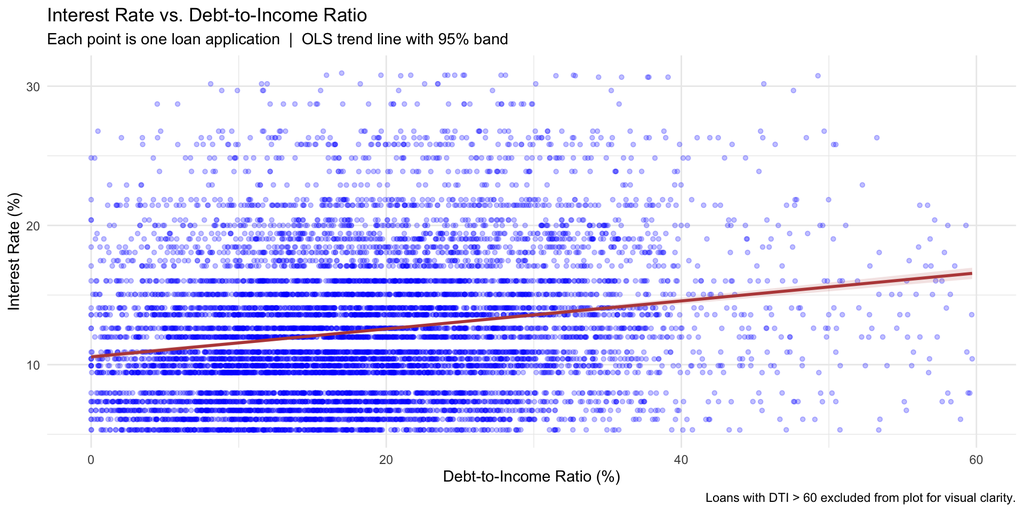

Figure 1: Scatter plot of interest rate versus debt-to-income ratio. A positive association is visible despite substantial dispersion.

```r
# Cap DTI at 60 to improve visual legibility (removes a handful of extreme outliers)
loans |>
  filter(debt_to_income <= 60) |>
  ggplot(aes(x = debt_to_income, y = interest_rate)) +
  geom_point(alpha = 0.25, color = plot_fill_brightblue, size = 1.2) +
  geom_smooth(method = "lm", color = plot_fill_crimson,
              linewidth = 1, se = TRUE, fill = plot_fill_crimson, alpha = 0.15) +
  labs(
    title    = "Interest Rate vs. Debt-to-Income Ratio",
    subtitle = "Each point is one loan application  |  OLS trend line with 95% band",
    x        = "Debt-to-Income Ratio (%)",
    y        = "Interest Rate (%)",
    caption  = "Loans with DTI > 60 excluded from plot for visual clarity."
  ) +
  theme(panel.background = element_rect(fill = plot_background, color = plot_greytext)) +
  theme_minimal()
```

### Frequentist Baseline

Before stepping into the Bayesian framework it is useful to establish a frequentist reference. The ordinary least squares model provides a single point estimate for the slope:

**Display code**

```r
ols_a <- lm(interest_rate ~ debt_to_income, data = loans)
summary(ols_a)
```

```
Call:
lm(formula = interest_rate ~ debt_to_income, data = loans)

Residuals:
     Min       1Q   Median       3Q      Max
-21.7391  -3.7203  -0.7945   2.7351  18.6274

Coefficients:
                Estimate Std. Error t value            Pr(>|t|)
(Intercept)    11.511445   0.080732  142.59 <0.0000000000000002 ***
debt_to_income  0.047183   0.003302   14.29 <0.0000000000000002 ***
---
Signif. codes:  0 '***' 0.001 '**' 0.01 '*' 0.05 '.' 0.1 ' ' 1

Residual standard error: 4.948 on 9974 degrees of freedom
Multiple R-squared:  0.02007,   Adjusted R-squared:  0.01997
F-statistic: 204.2 on 1 and 9974 DF,  p-value: < 0.00000000000000022
```

**Display code**

```r
get_parameters(ols_a)
```

| Parameter | Estimate |
| --- | --- |
| (Intercept) | 11.5114453 |
| debt_to_income | 0.0471828 |

**NoteFrequentist Reading**

### Fitting the Bayesian Model

`lm()` is replaced with `stan_glm()`. The likelihood and linear structure are identical; the difference is that `stan_glm()` uses a Markov Chain Monte Carlo (MCMC) algorithm to draw samples from the **posterior distribution** of each parameter rather than solving the normal equations for a single point estimate.

**Display code**

```r
bayes_a <- stan_glm(
  interest_rate ~ debt_to_income,
  data   = loans,
  family = gaussian(),
  seed   = 2024
)
```

**NoteWhat just happened under the hood?**

`stan_glm()` ran **4 independent chains**, each sampling **2,000 iterations** with the first 1,000 discarded as warm-up. The result is **4 × 1,000 = 4,000 posterior draws** per parameter — 4,000 plausible values for the DTI slope, each consistent with the observed data and the weakly informative priors.

### Extracting and Inspecting the Posterior

**Display code**

```r
post_a <- get_parameters(bayes_a)

cat("Posterior draws:", nrow(post_a), "\n\n")
```

```
Posterior draws: 4000
```

**Display code**

```r
head(post_a, 8)
```

| (Intercept) | debt_to_income |
| --- | --- |
| 11.54369 | 0.0425332 |
| 11.52041 | 0.0501907 |
| 11.58366 | 0.0416657 |
| 11.41310 | 0.0532105 |
| 11.37411 | 0.0525722 |
| 11.65359 | 0.0424119 |
| 11.56097 | 0.0454208 |
| 11.54989 | 0.0456075 |

Each row is a draw from the joint posterior — a single internally consistent guess at what the intercept *and* the DTI slope could plausibly be. The `debt_to_income` column isolates the marginal posterior for the slope that is most cared about.

### Visualising the Posterior Distribution

**Display code**

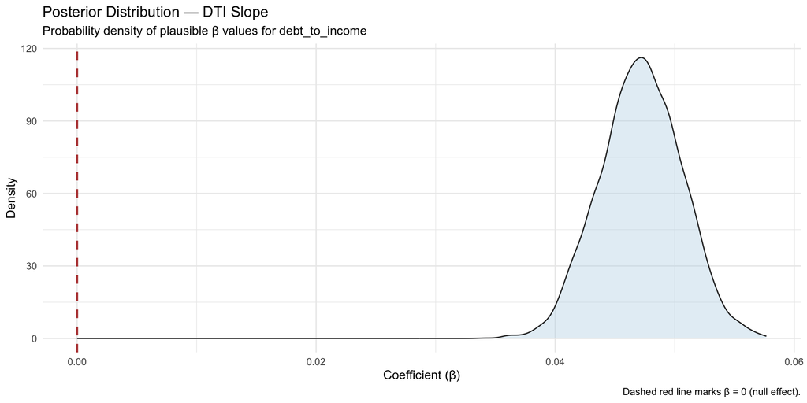

Figure 2: Posterior distribution of the debt-to-income slope coefficient. The bulk of the mass sits clearly above zero.

```r
ggplot(post_a, aes(x = debt_to_income)) +
  geom_density(fill = plot_fill_lightblue, color = plot_blacktext,
               alpha = 0.4, linewidth = 0.5) +
  geom_vline(xintercept = 0, color = plot_fill_crimson,
             linewidth = 0.9, linetype = "dashed") +
  labs(
    title    = "Posterior Distribution — DTI Slope",
    subtitle = "Probability density of plausible β values for debt_to_income",
    x        = "Coefficient (β)",
    y        = "Density",
    caption  = "Dashed red line marks β = 0 (null effect)."
  ) +
  theme(panel.background = element_rect(fill = plot_background, color = plot_greytext)) +
  theme_minimal()
```

The distribution is unimodal, roughly symmetric, and sits comfortably to the right of zero — providing immediate visual evidence that DTI carries a positive effect on interest rates.

## Part A — Characterising the Posterior

### Point Estimates

Three natural summaries of the posterior’s center are available:

**Display code**

```r
tibble(
  Estimator = c("Mean", "Median", "MAP (mode)"),
  Value = c(
    round(mean(post_a$debt_to_income), 5),
    round(median(post_a$debt_to_income), 5),
    round(as.numeric(map_estimate(post_a$debt_to_income)), 5)
  )
)
```

| Estimator | Value |
| --- | --- |
| Mean | 0.04716 |
| Median | 0.04718 |
| MAP (mode) | 0.04715 |

**Display code**

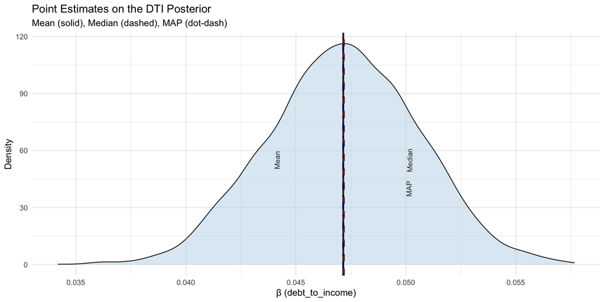

```r
pe_mean   <- mean(post_a$debt_to_income)
pe_median <- median(post_a$debt_to_income)
pe_map    <- as.numeric(map_estimate(post_a$debt_to_income))

ggplot(post_a, aes(x = debt_to_income)) +
  geom_density(fill = plot_fill_lightblue, color = plot_blacktext,
               alpha = 0.5, linewidth = 0.5) +
  geom_vline(xintercept = pe_mean,
             color = plot_blacktext,     linewidth = 1, linetype = "solid") +
  geom_vline(xintercept = pe_median,
             color = plot_redtext, linewidth = 1, linetype = "dashed") +
  geom_vline(xintercept = pe_map,
             color = plot_bluetext,   linewidth = 1, linetype = "dotdash") +
  annotate("text", x = pe_mean   - 0.003, y = 55, angle = 90,
           label = "Mean",   size = 3, color = plot_blacktext) +
  annotate("text", x = pe_median + 0.003, y = 55, angle = 90,
           label = "Median", size = 3, color = plot_blacktext) +
  annotate("text", x = pe_map    + 0.003, y = 40, angle = 90,
           label = "MAP",    size = 3, color = plot_blacktext) +
  labs(
    title    = "Point Estimates on the DTI Posterior",
    subtitle = "Mean (solid), Median (dashed), MAP (dot-dash)",
    x        = "β (debt_to_income)",
    y        = "Density"
  ) +
  theme(panel.background = element_rect(fill = plot_background, color = plot_greytext)) +
  theme_minimal()
```

**NoteWhich point estimate should be reported?**

All three are close enough here to make little practical difference. The **median** is the conventional recommendation in the Bayesian literature because it carries a clean probabilistic meaning: *there is a 50% probability the true slope exceeds this value and a 50% probability it falls below*. It is also more robust than the mean when posteriors are asymmetric or have heavy tails — both realistic conditions in financial data.

### Credible Intervals

A **credible interval** is the Bayesian analogue of a confidence interval, but with a far more intuitive interpretation. The **Highest Density Interval (HDI)** is used; it is the shortest continuous region of the posterior containing a specified probability mass.

**Display code**

```r
hdi(post_a$debt_to_income, ci = 0.89)
```

| CI | CI_low | CI_high |
| --- | --- | --- |
| 0.89 | 0.0413825 | 0.0522245 |

Given the observed loan data, there is an **89% probability** that the true effect of DTI on interest rate lies between these two bounds.

This is a direct statement about the parameter — not a long-run frequency claim about hypothetical replications. **89%** is used rather than 95% following Kruschke (2014) and McElreath (2018): the 89% level tends to produce more stable numerical estimates across sampling runs, and the choice of any threshold is inherently a convention worth questioning.

## Model B — Categorical Predictor: Homeownership → Interest Rate

### The Business Question

Does a borrower’s **homeownership status** affect the interest rate they receive? Lenders may view homeowners differently from renters — either as lower-risk borrowers (stable housing → stable finances) or as overextended ones (mortgage obligations reduce capacity). Bayesian inference quantifies that contrast and its uncertainty simultaneously.

### Sample Composition and Descriptives

**Display code**

```r
loans |>
  group_by(homeownership) |>
  summarise(
    n          = n(),
    mean_rate  = round(mean(interest_rate), 2),
    median_rate = round(median(interest_rate), 2),
    sd_rate    = round(sd(interest_rate), 2),
    .groups    = "drop"
  )
```

Table 2: Interest rate by homeownership category.

| homeownership | n | mean_rate | median_rate | sd_rate |
| --- | --- | --- | --- | --- |
| MORTGAGE | 4778 | 12.06 | 10.91 | 4.96 |
| RENT | 3848 | 12.92 | 11.99 | 5.03 |
| OWN | 1350 | 12.30 | 11.98 | 4.91 |

**Display code**

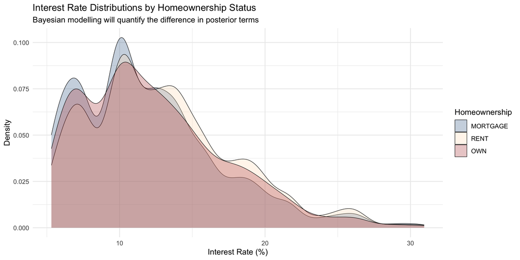

Figure 4: Distribution of interest rates by homeownership status. Renters tend to receive marginally higher rates; mortgage holders cluster slightly lower.

```r
ggplot(loans, aes(x = interest_rate, fill = homeownership)) +
  geom_density(alpha = 0.30, linewidth = 0.25) +
  scale_fill_manual(
    values = c("RENT"     = plot_fill_beige,
               "MORTGAGE" = plot_fill_blue,
               "OWN"      = plot_fill_crimson),
    name = "Homeownership"
  ) +
  labs(
    title    = "Interest Rate Distributions by Homeownership Status",
    subtitle = "Bayesian modelling will quantify the difference in posterior terms",
    x        = "Interest Rate (%)",
    y        = "Density"
  ) +
  theme(panel.background = element_rect(fill = plot_background, color = plot_greytext)) +
  theme_minimal()
```

### Frequentist Baseline

**Display code**

```r
ols_b <- lm(interest_rate ~ homeownership, data = loans)
summary(ols_b)
```

```
Call:
lm(formula = interest_rate ~ homeownership, data = loans)

Residuals:
   Min     1Q Median     3Q    Max
-7.609 -3.489 -0.929  2.984 18.884

Coefficients:
                  Estimate Std. Error t value             Pr(>|t|)
(Intercept)       12.05579    0.07208 167.261 < 0.0000000000000002 ***
homeownershipRENT  0.86321    0.10792   7.999   0.0000000000000014 ***
homeownershipOWN   0.24908    0.15357   1.622                0.105
---
Signif. codes:  0 '***' 0.001 '**' 0.01 '*' 0.05 '.' 0.1 ' ' 1

Residual standard error: 4.982 on 9973 degrees of freedom
Multiple R-squared:  0.006461,  Adjusted R-squared:  0.006261
F-statistic: 32.43 on 2 and 9973 DF,  p-value: 0.00000000000000919
```

**Display code**

```r
get_parameters(ols_b)
```

| Parameter | Estimate |
| --- | --- |
| (Intercept) | 12.0557911 |
| homeownershipRENT | 0.8632084 |
| homeownershipOWN | 0.2490755 |

The reference level is **MORTGAGE**. The coefficients for OWN and RENT represent the average difference in interest rate relative to mortgage-holding borrowers.

### Fitting the Bayesian Model

**Display code**

```r
bayes_b <- stan_glm(
  interest_rate ~ homeownership,
  data   = loans,
  family = gaussian(),
  seed   = 2024
)
```

### Extracting the Posterior Contrasts

**Display code**

```r
post_b <- get_parameters(bayes_b)
head(post_b, 6)
```

| (Intercept) | homeownershipRENT | homeownershipOWN |
| --- | --- | --- |
| 12.14299 | 0.7478868 | 0.2436291 |
| 12.16163 | 0.8051851 | 0.1314323 |
| 11.94826 | 0.9474287 | 0.3332836 |
| 11.96956 | 1.0124172 | 0.2723381 |
| 11.97925 | 0.9862999 | 0.3192978 |
| 12.03431 | 0.9094831 | 0.2383845 |

The two posterior columns — `homeownershipOWN` and `homeownershipRENT` — represent the distribution of plausible *differences* in interest rate relative to the MORTGAGE baseline. Every draw is a complete, internally consistent estimate of both contrasts.

### Visualising Both Contrasts

**Display code**

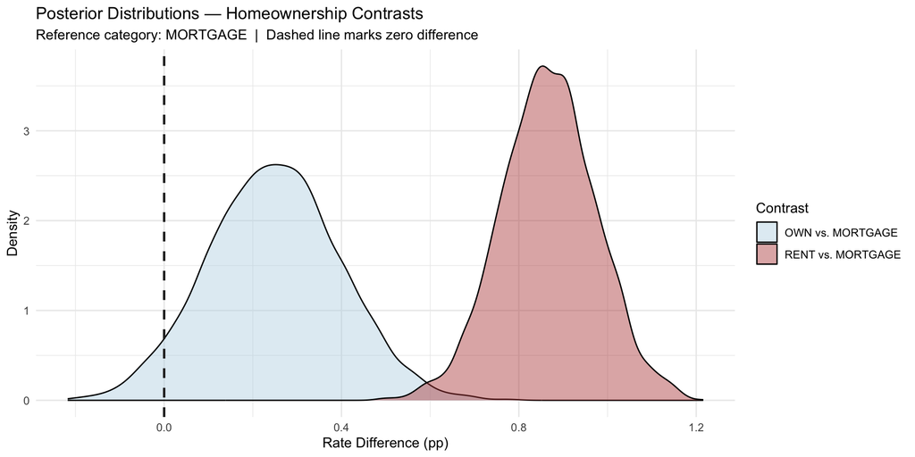

```r
post_b_long <- post_b |>
  select(homeownershipOWN, homeownershipRENT) |>
  pivot_longer(everything(),
               names_to  = "Contrast",
               values_to = "Estimate") |>
  mutate(Contrast = recode(Contrast,
                           homeownershipOWN  = "OWN vs. MORTGAGE",
                           homeownershipRENT = "RENT vs. MORTGAGE"))

ggplot(post_b_long, aes(x = Estimate, fill = Contrast)) +
  geom_density(alpha = 0.45, linewidth = 0.5) +
  geom_vline(xintercept = 0, color = plot_blacktext,
             linewidth = 0.9, linetype = "dashed") +
  scale_fill_manual(
    values = c("OWN vs. MORTGAGE"  = plot_fill_lightblue,
               "RENT vs. MORTGAGE" = plot_fill_crimson),
    name = "Contrast"
  ) +
  labs(
    title    = "Posterior Distributions — Homeownership Contrasts",
    subtitle = "Reference category: MORTGAGE  |  Dashed line marks zero difference",
    x        = "Rate Difference (pp)",
    y        = "Density"
  ) +
  theme(panel.background = element_rect(fill = plot_background, color = plot_greytext)) +
  theme_minimal()
```

## Part B — Characterising the Categorical Model Posterior

### Point Estimates and Credible Intervals

**Display code**

```r
tibble(
  Contrast  = c("OWN vs. MORTGAGE", "RENT vs. MORTGAGE"),
  Median    = c(round(median(post_b$homeownershipOWN), 3),
                round(median(post_b$homeownershipRENT), 3)),
  Mean      = c(round(mean(post_b$homeownershipOWN), 3),
                round(mean(post_b$homeownershipRENT), 3))
)
```

| Contrast | Median | Mean |
| --- | --- | --- |
| OWN vs. MORTGAGE | 0.248 | 0.248 |
| RENT vs. MORTGAGE | 0.866 | 0.867 |

**Display code**

```r
hdi(post_b$homeownershipOWN,  ci = 0.89)
```

| CI | CI_low | CI_high |
| --- | --- | --- |
| 0.89 | 0.0133243 | 0.4856739 |

**Display code**

```r
hdi(post_b$homeownershipRENT, ci = 0.89)
```

| CI | CI_low | CI_high |
| --- | --- | --- |
| 0.89 | 0.7057136 | 1.043158 |

### Region of Practical Equivalence (ROPE)

The **Region of Practical Equivalence** (ROPE) shifts the question from *“Is the effect non-zero?”* to *“Is the effect large enough to matter in practice?”* The ROPE is defined as the range of rate differences so small they carry no meaningful business or credit risk implications.

The standard data-driven approach uses **one-tenth of the response variable’s standard deviation** as the half-width:

**Display code**

```r
rope_bounds_b <- rope_range(bayes_b)
cat(sprintf("ROPE: [%.3f, %.3f] percentage points\n",
            rope_bounds_b[1], rope_bounds_b[2]))
```

```
ROPE: [-0.500, 0.500] percentage points
```

**Display code**

```r
rope(post_b$homeownershipOWN, range = rope_bounds_b, ci = 0.89)
```

| CI | ROPE_low | ROPE_high | ROPE_Percentage |
| --- | --- | --- | --- |
| 0.89 | -0.4997904 | 0.4997904 | 1 |

**Display code**

```r
rope(post_b$homeownershipRENT, range = rope_bounds_b, ci = 0.89)
```

| CI | ROPE_low | ROPE_high | ROPE_Percentage |
| --- | --- | --- | --- |
| 0.89 | -0.4997904 | 0.4997904 | 0 |

**NoteROPE interpretation for lending risk**

When **0% of the 89% credible interval falls inside the ROPE**, it can be concluded that the effect is *practically significant* — not merely statistically detectable. A ROPE overlap of more than 5–10% would suggest the effect, while real, may be too small to drive material pricing decisions.

In a lending context, a rate difference of less than ±0.5 percentage points would be considered commercially negligible. Any effect outside this band warrants attention in a pricing or risk model.

### Probability of Direction (pd)

Rather than a binary significant/non-significant verdict, the **Probability of Direction** (pd) provides a confidence level regarding the *sign* of an effect — the proportion of posterior draws on the same side of zero as the median.

**Display code**

```r
p_direction(post_b$homeownershipOWN)
```

| Parameter | pd |
| --- | --- |
| Posterior | 0.9535 |

**Display code**

```r
p_direction(post_b$homeownershipRENT)
```

| Parameter | pd |
| --- | --- |
| Posterior | 1 |

**NoteTranslating pd to familiar terms**

$$p_{\text{two-sided}} \approx 2 \times (1 - pd)$$

A pd of 99% corresponds to roughly *p* = 0.02 — but unlike the *p*-value, the pd has a natural language interpretation: *“There is a 99% probability that this effect is positive.”* No repeated-sampling thought experiment required.

## Unified Summary: `describe_posterior()`

Rather than assembling these indices one at a time, `bayestestR` provides `describe_posterior()` — a single function that computes the median, HDI, pd, ROPE percentage, Bayes Factor, and MCMC diagnostics in one call.

### Model A — Continuous (DTI)

**Display code**

```r
describe_posterior(
  bayes_a,
  test     = c("p_direction", "rope", "bayesfactor"),
  ci       = 0.89,
  ci_method = "HDI"
)
```

| Parameter | Median | CI | CI_low | CI_high | pd | ROPE_CI | ROPE_low | ROPE_high | ROPE_Percentage | log_BF | Rhat | ESS |
| --- | --- | --- | --- | --- | --- | --- | --- | --- | --- | --- | --- | --- |
| (Intercept) | 11.5100547 | 0.89 | 11.3701905 | 11.6327373 | 1 | 0.95 | -0.4997904 | 0.4997904 | 0 | 345.76807 | 0.9995702 | 3737.440 |
| debt_to_income | 0.0471812 | 0.89 | 0.0413825 | 0.0522245 | 1 | 0.95 | -0.4997904 | 0.4997904 | 1 | 26.76105 | 0.9997130 | 3968.526 |

### Model B — Categorical (Homeownership)

**Display code**

```r
describe_posterior(
  bayes_b,
  test      = c("p_direction", "rope", "bayesfactor"),
  ci        = 0.89,
  ci_method = "HDI"
)
```

|  | Parameter | Median | CI | CI_low | CI_high | pd | ROPE_CI | ROPE_low | ROPE_high | ROPE_Percentage | log_BF | Rhat | ESS |
| --- | --- | --- | --- | --- | --- | --- | --- | --- | --- | --- | --- | --- | --- |
| 1 | (Intercept) | 12.0529083 | 0.89 | 11.9368926 | 12.1678556 | 1.0000 | 0.95 | -0.4997904 | 0.4997904 | 0.00 | 425.519110 | 1.000554 | 3806.212 |
| 3 | homeownershipRENT | 0.8660581 | 0.89 | 0.7057136 | 1.0431579 | 1.0000 | 0.95 | -0.4997904 | 0.4997904 | 0.00 | 9.635037 | 1.000840 | 4758.075 |
| 2 | homeownershipOWN | 0.2477539 | 0.89 | 0.0133243 | 0.4856739 | 0.9535 | 0.95 | -0.4997904 | 0.4997904 | 0.98 | -4.094458 | 1.000246 | 4299.273 |

#### Reading the describe_posterior() output

**Display code**

```r
"Column" <- c(
            "Median",
            "CI_low / CI_high",
            "pd",
            "% in ROPE",
            "BF",
            "Rhat",
            "ESS")

"Interpretation" <- c(
            "Preferred point estimate; 50th percentile of the posterior",
            "89% HDI bounds — the highest-density region of the posterior",
            "Probability of Direction — confidence in the sign of the effect",
            "Share of the 89% HDI overlapping the practical-equivalence zone",
            "Bayes Factor — evidence ratio against a point-null model",
            "Convergence diagnostic; values ≤ 1.01 indicate good MCMC mixing",
            "Effective Sample Size; a proxy for posterior estimate precision"
            )

tblData <- tibble(Column, Interpretation)

kbl(tblData) %>%
  kable_styling(bootstrap_options = c("striped", "hover"))
```

| Column | Interpretation |
| --- | --- |
| Median | Preferred point estimate; 50th percentile of the posterior |
| CI_low / CI_high | 89% HDI bounds — the highest-density region of the posterior |
| pd | Probability of Direction — confidence in the sign of the effect |
| % in ROPE | Share of the 89% HDI overlapping the practical-equivalence zone |
| BF | Bayes Factor — evidence ratio against a point-null model |
| Rhat | Convergence diagnostic; values ≤ 1.01 indicate good MCMC mixing |
| ESS | Effective Sample Size; a proxy for posterior estimate precision |

## Insights & Conclusion

Two lending risk questions, two Bayesian models, one consistent framework:

From a credit risk standpoint, this distinction between RENT, OWN, and MORTGAGE borrowers matters in a nuanced way that is worth calling out here.

⦁ RENT borrowers have no housing asset on their personal balance sheet, which may signal lower net worth or less financial stability — hence the higher interest rates we see in the data.

⦁ MORTGAGE borrowers carry a secured debt obligation but also hold a real asset with equity, and lenders may view the discipline of consistent mortgage payments as a positive credit signal.

⦁ OWN borrowers might seem like the lowest-risk group (no housing debt, real asset fully owned), but in the lending data they often sit between RENT and MORTGAGE on interest rates — possibly because outright owners tend to be older or have lower incomes, or because their loan applications involve smaller amounts where lender pricing is less differentiated.

This last point — OWN not being the clear lowest-rate group — is actually an interesting finding and is highlighted since it runs counter to the naive intuition that zero housing debt = best credit profile.

The Bayesian approach adds dimensions of inference that frequentist regression structurally cannot provide. Here are the top three for risk stakeholders:

**1. A probability statement about the parameter, not just about the data**

The frequentist p-value answers a question no credit officer or risk committee ever actually asked: “If the true effect were exactly zero, how often would we observe data this extreme across infinite hypothetical replications?” The Bayesian posterior inverts this. After observing the loan data, we can say directly: “There is an 89% probability that the true DTI effect falls between these two values.” That is a statement about the parameter given the data — the direction of inference that matches how analysts and decision-makers actually think. Regulatory model risk governance frameworks increasingly require quantified uncertainty and explainable outputs; a posterior distribution satisfies both requirements more naturally than a point estimate with a significance star.

**2. A principled uncertainty envelope that is honest about data quality**

The 89% HDI is not a fixed-width band — it is a direct reflection of how much information the data actually contain. A wide HDI signals that many parameter values remain plausible; a narrow one signals the opposite. For a lending book, this is operationally useful: a model fit on a thin borrower segment will produce a wide HDI, which is itself information — a natural flag to treat that segment’s estimates with greater caution and more conservative pricing.

## References

Bray, A., Çetinkaya-Rundel, M., & Hardin, J. (2023). *openintro: Data sets and supplemental functions from OpenIntro textbooks*. R package. https://CRAN.R-project.org/package=openintro

Cohen, J. (1988). *Statistical power analysis for the social sciences* (2nd ed.). Lawrence Erlbaum.

Goodrich, B., Gabry, J., Ali, I., & Brilleman, S. (2023). *rstanarm: Bayesian applied regression modeling via Stan*. R package. https://mc-stan.org/rstanarm/

Kruschke, J. (2014). *Doing Bayesian data analysis: A tutorial with R, JAGS, and Stan* (2nd ed.). Academic Press.

Makowski, D., Ben-Shachar, M. S., & Lüdecke, D. (2019). bayestestR: Describing effects and their uncertainty, existence and significance within the Bayesian framework. *Journal of Open Source Software, 4*(40), 1541. https://doi.org/10.21105/joss.01541

McElreath, R. (2018). *Statistical rethinking: A Bayesian course with examples in R and Stan*. Chapman & Hall/CRC.

[session information not shown]

*Rendered with [Quarto](https://quarto.org/) · Packages: `bayestestR` `dplyr` `ggplot2` `insight` `kableExtra` `openintro` `rstanarm` `scales` `sessioninfo` `tidyr` `tidyverse`*